# A Diaz, Guzman, & Co. Xmas: Secret Santa 2018

David A. Diaz

# Introduction

- As always, everyone is randomly matched to another human (or to a Cindy, a dog, or a cat).
- Your mission is to buy a thoughtful gift for your Secret Santa to be given at our Christmas celebration on either December 24th or 25th.
- The dollar limit for this year’s big event is **$15**.

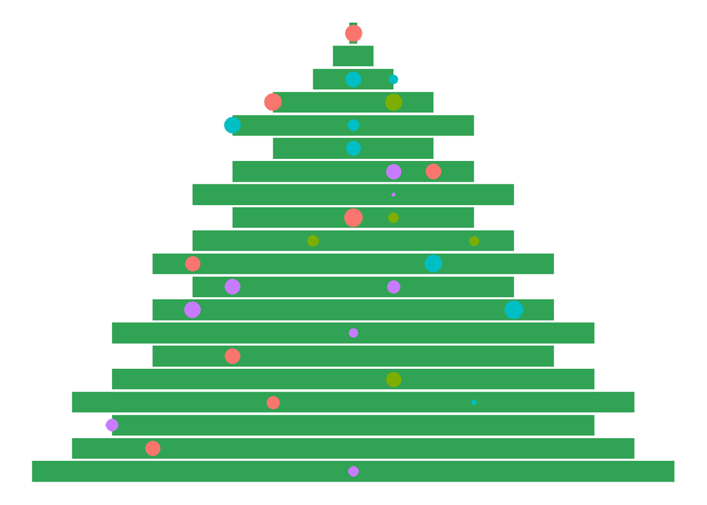

# The Participants

Let’s see who is participating this year:

[output not shown]

| Name |
| --- |
| Aaron Guzman |
| Abby Diaz |
| Adrian Guzman |
| Adriana Diaz |
| Ale Diaz |
| Ayden Guzman |
| Carlos Guzman |
| Cindy Diaz |
| Cookie Diaz |
| Dany Diaz |
| Estrella Diaz |
| Jony Guzman |
| Kelsey Hayes |
| Mama Letty |
| Mambo Guzman |
| Nando Guzman |
| Nella Guzman |
| Norma Guzman |
| Papa Lico |
| Rhina Guzman |
| Rigo Guzman |
| Rudy Sizer |
| Sarah Sizer |
| Sofia Escobar |
| Stella Diaz |
| Tio Juan |
| Tio Rigo |
| Tito Diaz |

# The Matching

An easy way to do the matching in **R** is to pick all the participants in random order and assign them to give a gift to the following person in the list. This helps to not have any self-matches that might occur in a “draw-a-name-out-of-a-hat” approach, though it does prevent any cross-gifting, i.e., no two people *i* and *j* can be each other’s Santa. I think that’s actually a nice feature - let’s mix it up!

I’ll show an example of how it works, but will use IDs instead of names to keep it generic.

```r
famID <- fam %>%
       # Assign ID to each person
       mutate(ID = sample(seq(100,200), length(fam$Name), replace=FALSE)) %>%
       select(ID) %>%
       # Randomly draw every ID
       mutate(ID = sample(ID)) %>%
      # Pick the next ID in list as their partner
       mutate(Partner_ID = lag(ID))

# Assign remaining partner to first person in list
famID$Partner_ID[1] <- famID$ID[nrow(famID)]

# Show table
famID %>% kable(align='l') %>% kable_styling(bootstrap_options = "striped")
```

| ID | Partner_ID |
| --- | --- |
| 192 | 138 |
| 161 | 192 |
| 146 | 161 |
| 196 | 146 |
| 109 | 196 |
| 111 | 109 |
| 122 | 111 |
| 183 | 122 |
| 165 | 183 |
| 108 | 165 |
| 175 | 108 |
| 181 | 175 |
| 185 | 181 |
| 133 | 185 |
| 168 | 133 |
| 184 | 168 |
| 105 | 184 |
| 141 | 105 |
| 200 | 141 |
| 147 | 200 |
| 139 | 147 |
| 153 | 139 |
| 121 | 153 |
| 120 | 121 |
| 164 | 120 |
| 151 | 164 |
| 125 | 151 |
| 138 | 125 |

# The Final Results

The code that generates the final Secret Santa matches is shown below. Note that this will generate a new partner each time it is run - so don’t try it at home and expect the partners to be the same as in the final run!

```r
# Set seed for reproducing matches - good luck guessing my number :)
# set.seed()

fam <- fam %>%
       select(Name) %>%
       mutate(Name = sample(Name)) %>%
       mutate(Partner = lag(Name))

fam$Partner[1] <- fam$Name[nrow(fam)]
```